# Maciak Arkadiusz - PD3

Arkadiusz Maciak

2023-03-28

## Wstęp

Eksperyment przeprowadzony przeze mnie polegał na sprawdzeniu różnic w odczytywaniu i czytelności wykresów kołowych (3D) i słupkowych. Wykresy wykorzystane w eksperymencie opierają się na zbiorze auta2012 z paczki danych PogromcyDanych i dotyczą liczby samochodów w zależności od kraju pochodzenia. Różnice w odczytywaniu wykresów sprawdzone zostały na (niewielkiej) grupie ludzi z wykorzystaniem ankiety.

## Wykresy

### Wykres kołowy 3D

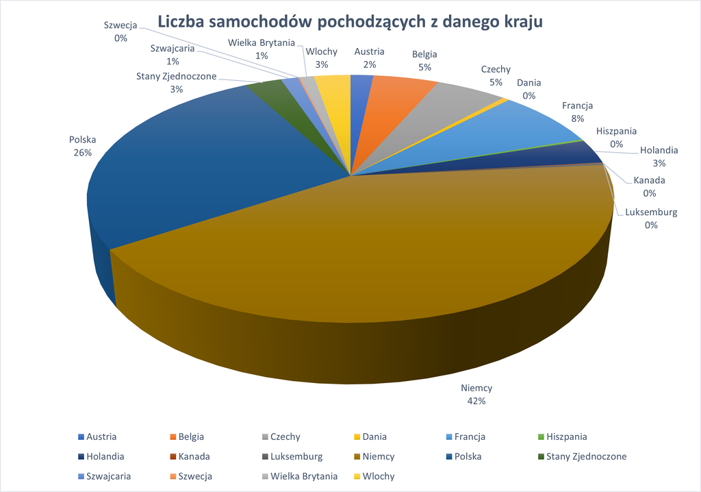

### Wykres słupkowy

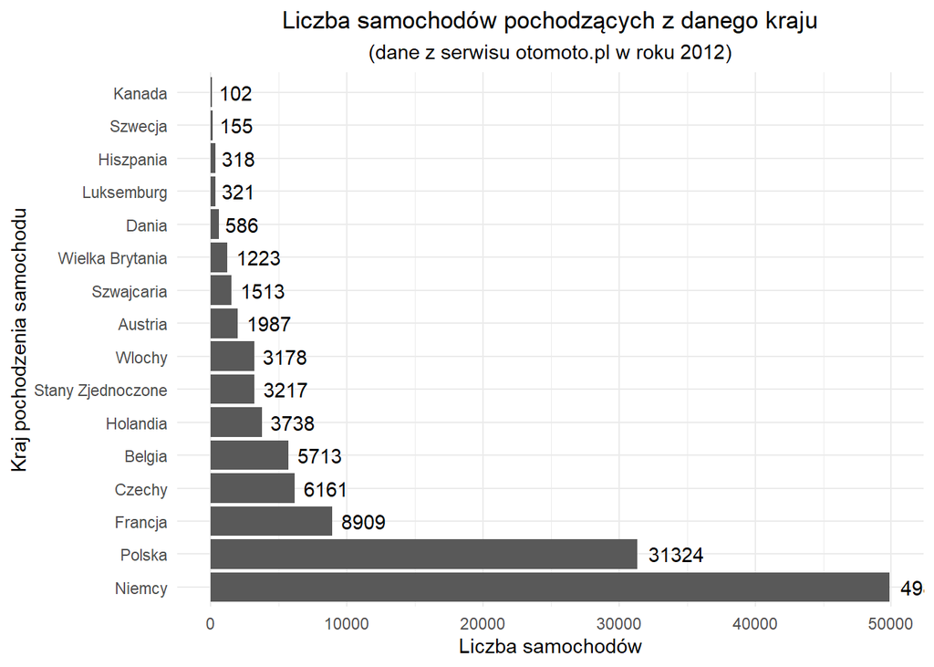

## Ankieta - informacje ogólne

Ankieta została przeprowadzona na 20 osobach. Zawierała pytania na temat różnych informacji, które można odczytać z wykresów oraz personalnej opinii ankietowanych na temat ich czytelności. Na początku przedstawione zostały pytania o wykres kołowy (gorszy, trudniejszy do odczytania), następnie o wykres słupkowy (czytelniejszy, lepiej przedstawiający wybrane dane). Kolejność ta nie była przypadkowa - chciałem uniknąć w sytuacji, w której osoba ankietowana sugeruje się informacjami z wykresu czytelniejszego, na którym lepiej widać zależności między danymi (czyli wykresem słupkowym). Pytania do obu wykresów były jednakowe. Na każde pytanie o informacje z wykresów była jedna, poprawna odpowiedź.

## Pytania w ankiecie

Lista pytań zawartych w ankiecie:

1. Samochodów z którego kraju jest najwięcej?
2. Samochodów z którego kraju jest najmniej?
3. Samochodów z którego kraju jest więcej - z Hiszpanii, czy Szwecji?
4. Samochodów z którego kraju jest więcej - z Szwajcarii czy Wielkiej Brytanii?
5. Samochodów z którego kraju jest więcej - z Włoch czy Stanów Zjednoczonych?
6. Samochodów z którego kraju jest więcej - z Czechy czy Belgi?
7. Czy uważasz, że wykres ten jest czytelny i łatwo pozyskać z niego informacje?

## Wyniki ankiety

Tak prezentują się wyniki ankiety (dla pytań 1-6 - pytań o informacje z wykresów):

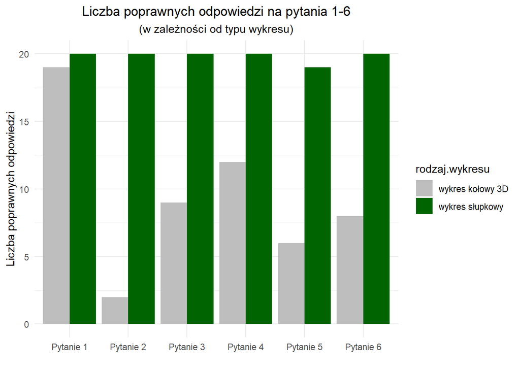

Tak prezentują się wyniki ankiety dla pytania 7 (pytanie o czytelność wykresu):

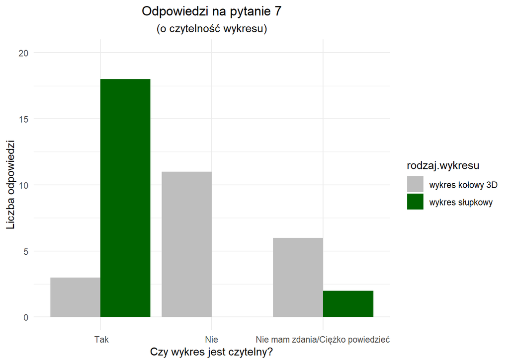

## Wnioski

Z wyników ankiety można ewidentnie wywnioskować, że wykres słupkowy jest o wiele bardziej czytelny i łatwiej z niego odczytać dane, bądź zależności między poszczególnymi zmiennymi. Wykres kołowy nie jest dobrym wyborem, kiedy mamy tak dużo zmiennych jakościowych (o wiele czytelniejszy jest wtedy wykres słupkowy).